# IBM HR Analytics Employee Attrition & Performance

```python
import pandas as pd
import numpy as np
import matplotlib
import matplotlib.pyplot as plt
import seaborn as sns
import os
import sys
import time
```

```python
import warnings
warnings.filterwarnings("ignore")
```

Setting the seed value

```python
def print_versions():
    print("pandas version: ", pd.__version__)
    print("numpy version: ", np.__version__)
    print("matplotlib version: ", matplotlib.__version__)
    print("seaborn version: ", sns.__version__)
    print("python version: ", sys.version)

print_versions()
```

```
pandas version:  1.4.2
numpy version:  1.21.5
matplotlib version:  3.5.1
seaborn version:  0.11.2
python version:  3.9.12 (main, Apr  4 2022, 05:22:27) [MSC v.1916 64 bit (AMD64)]
```

```python
!pip list
```

[output not shown]

[output cut: 295 more lines]

[output not shown]

```python
!pip freeze
```

[output not shown]

[output cut: 290 more lines]

[output not shown]

```python
np.random.seed(12345)
```

## Exploratory Data Analysis

Data Analysis and Visualization

```python
employee_data = pd.read_csv("HR-Employee-Attrition.csv")
```

```python
employee_data.info()
```

```
<class 'pandas.core.frame.DataFrame'>
RangeIndex: 1470 entries, 0 to 1469
Data columns (total 35 columns):
 #   Column                    Non-Null Count  Dtype
---  ------                    --------------  -----
 0   Age                       1470 non-null   int64
 1   Attrition                 1470 non-null   object
 2   BusinessTravel            1470 non-null   object
 3   DailyRate                 1470 non-null   int64
 4   Department                1470 non-null   object
 5   DistanceFromHome          1470 non-null   int64
 6   Education                 1470 non-null   int64
 7   EducationField            1470 non-null   object
 8   EmployeeCount             1470 non-null   int64
 9   EmployeeNumber            1470 non-null   int64
```

[output cut: 27 more lines]

```python
employee_data.head()
```

|  | Age | Attrition | BusinessTravel | DailyRate | Department | DistanceFromHome | Education | EducationField | EmployeeCount | EmployeeNumber | ... | RelationshipSatisfaction | StandardHours | StockOptionLevel | TotalWorkingYears | TrainingTimesLastYear | WorkLifeBalance | YearsAtCompany | YearsInCurrentRole | YearsSinceLastPromotion | YearsWithCurrManager |
| --- | --- | --- | --- | --- | --- | --- | --- | --- | --- | --- | --- | --- | --- | --- | --- | --- | --- | --- | --- | --- | --- |
| 0 | 41 | Yes | Travel_Rarely | 1102 | Sales | 1 | 2 | Life Sciences | 1 | 1 | ... | 1 | 80 | 0 | 8 | 0 | 1 | 6 | 4 | 0 | 5 |
| 1 | 49 | No | Travel_Frequently | 279 | Research & Development | 8 | 1 | Life Sciences | 1 | 2 | ... | 4 | 80 | 1 | 10 | 3 | 3 | 10 | 7 | 1 | 7 |
| 2 | 37 | Yes | Travel_Rarely | 1373 | Research & Development | 2 | 2 | Other | 1 | 4 | ... | 2 | 80 | 0 | 7 | 3 | 3 | 0 | 0 | 0 | 0 |
| 3 | 33 | No | Travel_Frequently | 1392 | Research & Development | 3 | 4 | Life Sciences | 1 | 5 | ... | 3 | 80 | 0 | 8 | 3 | 3 | 8 | 7 | 3 | 0 |
| 4 | 27 | No | Travel_Rarely | 591 | Research & Development | 2 | 1 | Medical | 1 | 7 | ... | 4 | 80 | 1 | 6 | 3 | 3 | 2 | 2 | 2 | 2 |

5 rows × 35 columns

```python
employee_data.describe()
```

|  | Age | DailyRate | DistanceFromHome | Education | EmployeeCount | EmployeeNumber | EnvironmentSatisfaction | HourlyRate | JobInvolvement | JobLevel | ... | RelationshipSatisfaction | StandardHours | StockOptionLevel | TotalWorkingYears | TrainingTimesLastYear | WorkLifeBalance | YearsAtCompany | YearsInCurrentRole | YearsSinceLastPromotion | YearsWithCurrManager |
| --- | --- | --- | --- | --- | --- | --- | --- | --- | --- | --- | --- | --- | --- | --- | --- | --- | --- | --- | --- | --- | --- |
| count | 1470.000000 | 1470.000000 | 1470.000000 | 1470.000000 | 1470.0 | 1470.000000 | 1470.000000 | 1470.000000 | 1470.000000 | 1470.000000 | ... | 1470.000000 | 1470.0 | 1470.000000 | 1470.000000 | 1470.000000 | 1470.000000 | 1470.000000 | 1470.000000 | 1470.000000 | 1470.000000 |
| mean | 36.923810 | 802.485714 | 9.192517 | 2.912925 | 1.0 | 1024.865306 | 2.721769 | 65.891156 | 2.729932 | 2.063946 | ... | 2.712245 | 80.0 | 0.793878 | 11.279592 | 2.799320 | 2.761224 | 7.008163 | 4.229252 | 2.187755 | 4.123129 |
| std | 9.135373 | 403.509100 | 8.106864 | 1.024165 | 0.0 | 602.024335 | 1.093082 | 20.329428 | 0.711561 | 1.106940 | ... | 1.081209 | 0.0 | 0.852077 | 7.780782 | 1.289271 | 0.706476 | 6.126525 | 3.623137 | 3.222430 | 3.568136 |
| min | 18.000000 | 102.000000 | 1.000000 | 1.000000 | 1.0 | 1.000000 | 1.000000 | 30.000000 | 1.000000 | 1.000000 | ... | 1.000000 | 80.0 | 0.000000 | 0.000000 | 0.000000 | 1.000000 | 0.000000 | 0.000000 | 0.000000 | 0.000000 |
| 25% | 30.000000 | 465.000000 | 2.000000 | 2.000000 | 1.0 | 491.250000 | 2.000000 | 48.000000 | 2.000000 | 1.000000 | ... | 2.000000 | 80.0 | 0.000000 | 6.000000 | 2.000000 | 2.000000 | 3.000000 | 2.000000 | 0.000000 | 2.000000 |
| 50% | 36.000000 | 802.000000 | 7.000000 | 3.000000 | 1.0 | 1020.500000 | 3.000000 | 66.000000 | 3.000000 | 2.000000 | ... | 3.000000 | 80.0 | 1.000000 | 10.000000 | 3.000000 | 3.000000 | 5.000000 | 3.000000 | 1.000000 | 3.000000 |
| 75% | 43.000000 | 1157.000000 | 14.000000 | 4.000000 | 1.0 | 1555.750000 | 4.000000 | 83.750000 | 3.000000 | 3.000000 | ... | 4.000000 | 80.0 | 1.000000 | 15.000000 | 3.000000 | 3.000000 | 9.000000 | 7.000000 | 3.000000 | 7.000000 |
| max | 60.000000 | 1499.000000 | 29.000000 | 5.000000 | 1.0 | 2068.000000 | 4.000000 | 100.000000 | 4.000000 | 5.000000 | ... | 4.000000 | 80.0 | 3.000000 | 40.000000 | 6.000000 | 4.000000 | 40.000000 | 18.000000 | 15.000000 | 17.000000 |

8 rows × 26 columns

```python
employee_data.nunique().sort_values(ascending=True)
```

```
Over18                         1
StandardHours                  1
EmployeeCount                  1
Gender                         2
Attrition                      2
PerformanceRating              2
OverTime                       2
MaritalStatus                  3
Department                     3
BusinessTravel                 3
StockOptionLevel               4
EnvironmentSatisfaction        4
JobInvolvement                 4
JobSatisfaction                4
RelationshipSatisfaction       4
WorkLifeBalance                4
Education                      5
JobLevel                       5
EducationField                 6
TrainingTimesLastYear          7
JobRole                        9
NumCompaniesWorked            10
PercentSalaryHike             15
YearsSinceLastPromotion       16
YearsWithCurrManager          18
YearsInCurrentRole            19
DistanceFromHome              29
YearsAtCompany                37
TotalWorkingYears             40
Age                           43
HourlyRate                    71
DailyRate                    886
MonthlyIncome               1349
MonthlyRate                 1427
EmployeeNumber              1470
dtype: int64
```

#### Age Density of IBM Employees

The Retirement Attrition has a been a common problem since.\ This type of Attrition happens when employees reach their stage of life or retirement.\ In this plot we look at the Age Distribution (Density) of the Employees

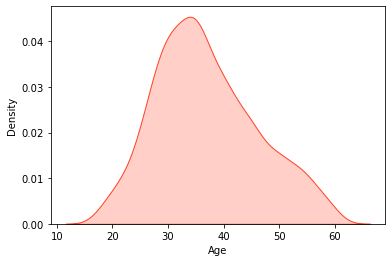

```python
# Age distrubition
sns.kdeplot(employee_data['Age'],shade=True,color='#ff4125')
```

#### Count of Attritions (Yes/No)

The amount of Attrition values in our dataset.\ How many of the emplooyes state that they have attrition?\ Also this countplot describes how imbalanced our dataset is.

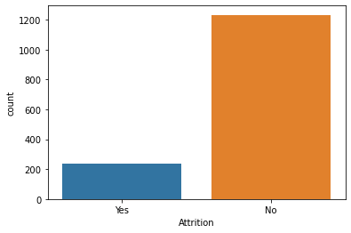

```python
# Investigating if the attrition level is really high.
sns.countplot(x="Attrition", data=employee_data)
plt.show()
```

#### Monthly Income and Gender/Attrition

"Gender Inequality" and "Gender Gap" are common topics these days.\ I wanted to analyze the Gender and Monthly Income that is supported with Attrition Rate.\ Giving an idea of these two topics

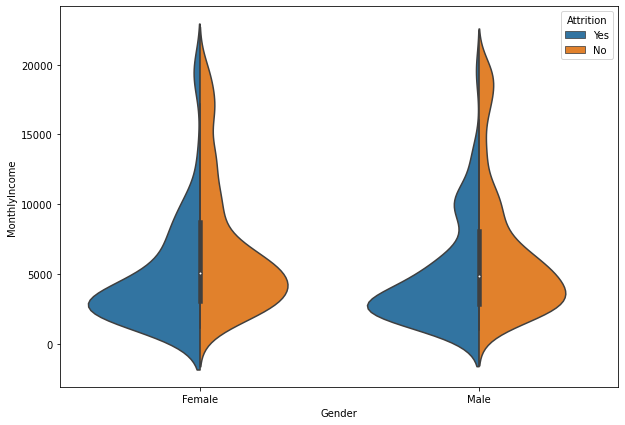

```python
# This figure was to show the difference between the Monthly
# Income and the gender/attrition
fig,ax = plt.subplots(figsize=(10,7))
sns.violinplot(x='Gender', y='MonthlyIncome',hue='Attrition',split=True,data=employee_data)
```

#### Relation of Age-DailyRate to the Attrition of Employees

In this plot we are analyzing DailyRate-Age distribution with attrition values.\ Showing the distribution of the DailyRate to Age and the areas that employees have attrition

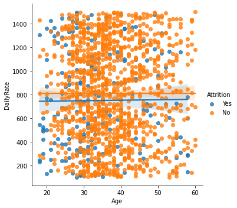

```python
# The relation of Age-DailyRate to the attrition of the employee
sns.lmplot(x = 'Age', y = 'DailyRate', hue = 'Attrition', data = employee_data)
plt.show()
```

#### Education Field Ratio of Employees

There has been a wide variety of new job opportunities in the most of the fields nowadays.\ So, this pie plot shows what are the education fields of the employees

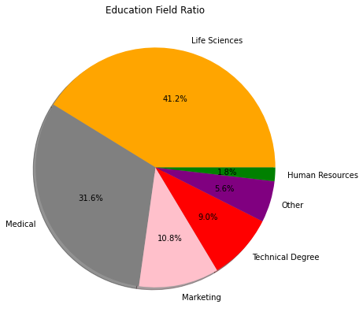

```python
val_counts = employee_data.EducationField.value_counts()
labels = val_counts.index
size_labels = val_counts.values
colors = ["orange", "grey", "pink", "red", "purple", "green"]
plt.figure(figsize=(7,7))
plt.pie(size_labels,
        labels=labels,
        colors=colors,
        autopct="%1.1f%%",
        shadow=True)
plt.title("Education Field Ratio")
```

#### The amount of Attrition to Job Satisfaction Points

Job Satisfaction - Attrition Rate

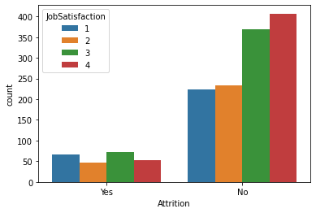

```python
sns.countplot(x="Attrition", hue='JobSatisfaction', data=employee_data)
plt.show()
```

#### Important Features about IBM and Personels to Attrition Amount

Some important features of employees and the attrition rates.\ For example job involvement which can easily lead to attrition

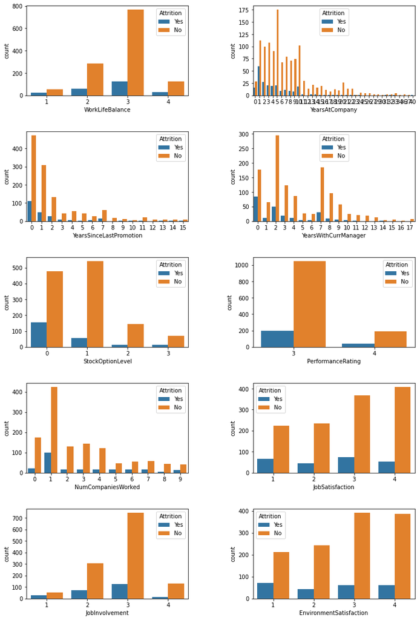

```python
column_labels = [
 "WorkLifeBalance",
 "YearsAtCompany",
 "YearsSinceLastPromotion",
 "YearsWithCurrManager",
 "StockOptionLevel",
 "PerformanceRating",
 "NumCompaniesWorked",
 "JobSatisfaction",
 "JobInvolvement",
 "EnvironmentSatisfaction"
]
plt.figure(figsize=(12,30))
for ind,col in enumerate(column_labels):
    plt.subplot(8,2,ind+1)
    sns.countplot(x=col, hue="Attrition", data=employee_data)
plt.subplots_adjust(left=0.1,
                    bottom=0.1,
                    right=0.9,
                    top=0.9,
                    wspace=0.4,
                    hspace=0.4)
```

#### Work Life Balance / Distance From Home and Attrition

Work-Life Balance is one of the most important aspects of life\ It is often stated that people who spent a lof of time on the roads have much more less time besides work.\ In the figure below I compared these attributes to the attrition of the employees

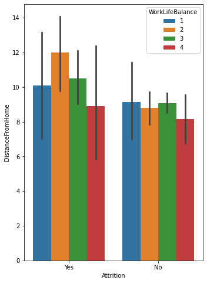

```python
plt.figure(figsize=(12,8))

plt.subplot(1,2,1)
sns.barplot(x="Attrition", y="DistanceFromHome", hue="WorkLifeBalance", data=employee_data)
```

Attrition rate over departments.\ Indicating if there is a particular department that have the rates higher than the others.

```python
pd.crosstab(columns=[employee_data.Attrition],index=[employee_data.Department],margins=True,normalize='index')
```

| Attrition Department | No | Yes |
| --- | --- | --- |
| Human Resources | 0.809524 | 0.190476 |
| Research & Development | 0.861602 | 0.138398 |
| Sales | 0.793722 | 0.206278 |
| All | 0.838776 | 0.161224 |

```python
pd.crosstab(columns=[employee_data.Attrition],index=[employee_data.JobLevel],margins=True,normalize='index')
```

| Attrition JobLevel | No | Yes |
| --- | --- | --- |
| 1 | 0.736648 | 0.263352 |
| 2 | 0.902622 | 0.097378 |
| 3 | 0.853211 | 0.146789 |
| 4 | 0.952830 | 0.047170 |
| 5 | 0.927536 | 0.072464 |
| All | 0.838776 | 0.161224 |

## Data Processing

Feature Selection, Normalization, Scaling etc.

```python
employee_data.drop("EmployeeNumber",axis=1,inplace=True)
employee_data.drop("Over18", axis=1, inplace=True)
employee_data.drop("EmployeeCount", axis=1, inplace=True)
employee_data.drop("StandardHours", axis=1, inplace=True)
```

Numerizing Attrition and Travel values (Not essential but wanted to do it manually)

```python
employee_data['Attrition'] = np.where(employee_data['Attrition'] == 'No',0,1)
```

```python
employee_data['BusinessTravel'].replace('Travel_Rarely',1, inplace=True)
employee_data['BusinessTravel'].replace('Travel_Frequently',3, inplace=True)
employee_data['BusinessTravel'].replace('Non-Travel',2, inplace=True)
```

```python
employee_data.head()
```

|  | Age | Attrition | BusinessTravel | DailyRate | Department | DistanceFromHome | Education | EducationField | EnvironmentSatisfaction | Gender | ... | PerformanceRating | RelationshipSatisfaction | StockOptionLevel | TotalWorkingYears | TrainingTimesLastYear | WorkLifeBalance | YearsAtCompany | YearsInCurrentRole | YearsSinceLastPromotion | YearsWithCurrManager |
| --- | --- | --- | --- | --- | --- | --- | --- | --- | --- | --- | --- | --- | --- | --- | --- | --- | --- | --- | --- | --- | --- |
| 0 | 41 | 1 | 1 | 1102 | Sales | 1 | 2 | Life Sciences | 2 | Female | ... | 3 | 1 | 0 | 8 | 0 | 1 | 6 | 4 | 0 | 5 |
| 1 | 49 | 0 | 3 | 279 | Research & Development | 8 | 1 | Life Sciences | 3 | Male | ... | 4 | 4 | 1 | 10 | 3 | 3 | 10 | 7 | 1 | 7 |
| 2 | 37 | 1 | 1 | 1373 | Research & Development | 2 | 2 | Other | 4 | Male | ... | 3 | 2 | 0 | 7 | 3 | 3 | 0 | 0 | 0 | 0 |
| 3 | 33 | 0 | 3 | 1392 | Research & Development | 3 | 4 | Life Sciences | 4 | Female | ... | 3 | 3 | 0 | 8 | 3 | 3 | 8 | 7 | 3 | 0 |
| 4 | 27 | 0 | 1 | 591 | Research & Development | 2 | 1 | Medical | 1 | Male | ... | 3 | 4 | 1 | 6 | 3 | 3 | 2 | 2 | 2 | 2 |

5 rows × 31 columns

Correlation matrix function to show the correlation between the attributes.

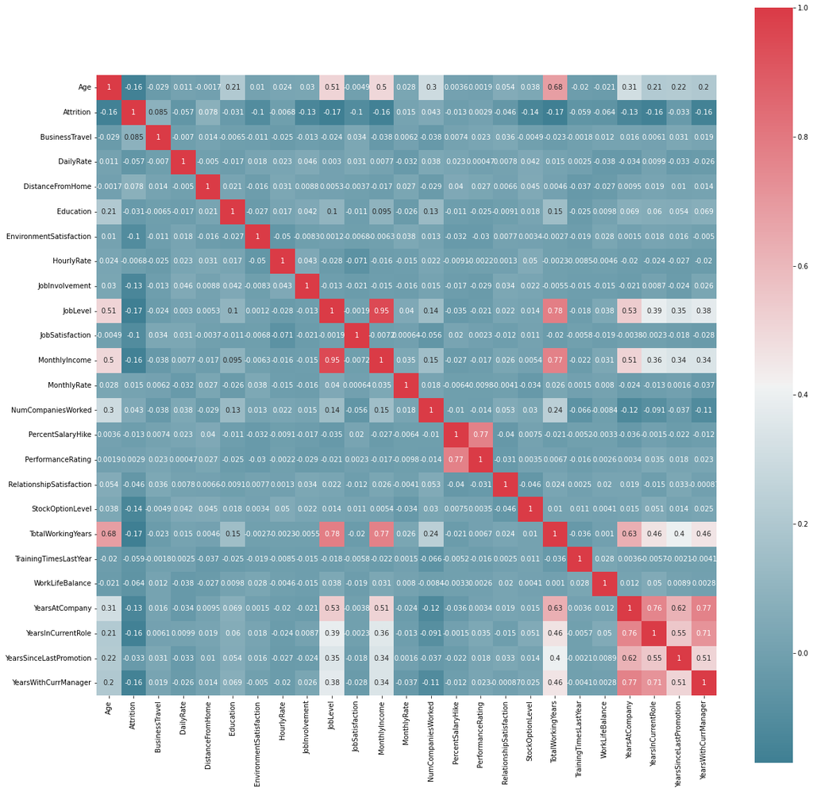

```python
def employee_data_correlation_mat():
    corr_matrix = employee_data.corr()
    f , ax = plt.subplots(figsize=(20,20))
    sns.heatmap(corr_matrix,mask=np.zeros_like(corr_matrix, dtype=bool),
                cmap=sns.diverging_palette(220, 10, as_cmap=True),
                square=True,
                ax=ax,
                annot=True)

employee_data_correlation_mat()
```

Attributes that are completely uncorrelated with others:\ Daily Rate, Hourly Rate, Monthly Rate

We want to get rid of highly correlated attributes since they happen to effect our dataset the same.\ Of course, we don't want to lose important features while doing so.\

Another important point here is that Rate attributes such as DailyRate is not correlated with other features.\ Thus, dropping those features will help our model.

```python
features_to_drop = [
    "DailyRate",
    "HourlyRate",
    "MonthlyRate",
    "PercentSalaryHike",
    "YearsInCurrentRole",
    "YearsAtCompany",
    "YearsWithCurrManager",
    "TotalWorkingYears",
    "JobLevel"
]

for col in features_to_drop:
    employee_data.drop(col, axis=1, inplace=True)
```

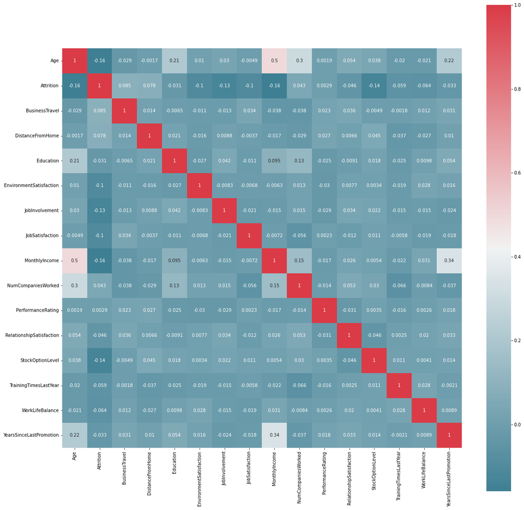

```python
employee_data_correlation_mat()
```

Label encoding for non-numeric features in our dataset

```python
from sklearn.preprocessing import LabelEncoder
def transform(feature):
    le=LabelEncoder()
    employee_data[feature]=le.fit_transform(employee_data[feature])
    print(le.classes_)
```

```python
df_columns = employee_data.columns
df_columns
```

```
Index(['Age', 'Attrition', 'BusinessTravel', 'Department', 'DistanceFromHome',
       'Education', 'EducationField', 'EnvironmentSatisfaction', 'Gender',
       'JobInvolvement', 'JobRole', 'JobSatisfaction', 'MaritalStatus',
       'MonthlyIncome', 'NumCompaniesWorked', 'OverTime', 'PerformanceRating',
       'RelationshipSatisfaction', 'StockOptionLevel', 'TrainingTimesLastYear',
       'WorkLifeBalance', 'YearsSinceLastPromotion'],
      dtype='object')
```

```python
df_object_columns = employee_data.select_dtypes(include='object').columns
for col in df_object_columns:
    transform(col)
```

```
['Human Resources' 'Research & Development' 'Sales']
['Human Resources' 'Life Sciences' 'Marketing' 'Medical' 'Other'
 'Technical Degree']
['Female' 'Male']
['Healthcare Representative' 'Human Resources' 'Laboratory Technician'
 'Manager' 'Manufacturing Director' 'Research Director'
 'Research Scientist' 'Sales Executive' 'Sales Representative']
['Divorced' 'Married' 'Single']
['No' 'Yes']
```

```python
employee_data.head()
```

|  | Age | Attrition | BusinessTravel | Department | DistanceFromHome | Education | EducationField | EnvironmentSatisfaction | Gender | JobInvolvement | ... | MaritalStatus | MonthlyIncome | NumCompaniesWorked | OverTime | PerformanceRating | RelationshipSatisfaction | StockOptionLevel | TrainingTimesLastYear | WorkLifeBalance | YearsSinceLastPromotion |
| --- | --- | --- | --- | --- | --- | --- | --- | --- | --- | --- | --- | --- | --- | --- | --- | --- | --- | --- | --- | --- | --- |
| 0 | 41 | 1 | 1 | 2 | 1 | 2 | 1 | 2 | 0 | 3 | ... | 2 | 5993 | 8 | 1 | 3 | 1 | 0 | 0 | 1 | 0 |
| 1 | 49 | 0 | 3 | 1 | 8 | 1 | 1 | 3 | 1 | 2 | ... | 1 | 5130 | 1 | 0 | 4 | 4 | 1 | 3 | 3 | 1 |
| 2 | 37 | 1 | 1 | 1 | 2 | 2 | 4 | 4 | 1 | 2 | ... | 2 | 2090 | 6 | 1 | 3 | 2 | 0 | 3 | 3 | 0 |
| 3 | 33 | 0 | 3 | 1 | 3 | 4 | 1 | 4 | 0 | 3 | ... | 1 | 2909 | 1 | 1 | 3 | 3 | 0 | 3 | 3 | 3 |
| 4 | 27 | 0 | 1 | 1 | 2 | 1 | 3 | 1 | 1 | 3 | ... | 1 | 3468 | 9 | 0 | 3 | 4 | 1 | 3 | 3 | 2 |

5 rows × 22 columns

```python
np.mean(employee_data, axis=0)
```

```
Age                           36.923810
Attrition                      0.161224
BusinessTravel                 1.478912
Department                     1.260544
DistanceFromHome               9.192517
Education                      2.912925
EducationField                 2.247619
EnvironmentSatisfaction        2.721769
Gender                         0.600000
JobInvolvement                 2.729932
JobRole                        4.458503
JobSatisfaction                2.728571
MaritalStatus                  1.097279
MonthlyIncome               6502.931293
NumCompaniesWorked             2.693197
OverTime                       0.282993
PerformanceRating              3.153741
RelationshipSatisfaction       2.712245
StockOptionLevel               0.793878
TrainingTimesLastYear          2.799320
WorkLifeBalance                2.761224
YearsSinceLastPromotion        2.187755
dtype: float64
```

Scaling some features that have a wide range of values.

```python
employee_data.min()
```

```
Age                           18
Attrition                      0
BusinessTravel                 1
Department                     0
DistanceFromHome               1
Education                      1
EducationField                 0
EnvironmentSatisfaction        1
Gender                         0
JobInvolvement                 1
JobRole                        0
JobSatisfaction                1
MaritalStatus                  0
MonthlyIncome               1009
NumCompaniesWorked             0
OverTime                       0
PerformanceRating              3
RelationshipSatisfaction       1
StockOptionLevel               0
TrainingTimesLastYear          0
WorkLifeBalance                1
YearsSinceLastPromotion        0
dtype: int64
```

```python
from sklearn.preprocessing import MinMaxScaler

scaler = MinMaxScaler()

employee_data['Age'] = scaler.fit_transform(employee_data[['Age']])
employee_data['MonthlyIncome'] = scaler.fit_transform(employee_data[['MonthlyIncome']])
```

## Train/Test Split

```python
X = employee_data.drop("Attrition", axis=1)
y = employee_data["Attrition"]
```

```python
from sklearn.model_selection import train_test_split

np.random.seed(12345)

X_train, X_test, y_train, y_test = train_test_split(X,y,test_size=0.15,stratify=y)
```

```python
X_train.shape
```

```
(1249, 21)
```

```python
X_test.shape
```

```
(221, 21)
```

```python
y
```

```
0       1
1       0
2       1
3       0
4       0
       ..
1465    0
1466    0
1467    0
1468    0
1469    0
Name: Attrition, Length: 1470, dtype: int32
```

```python
from sklearn.model_selection import StratifiedKFold

skfold = StratifiedKFold(n_splits=5, random_state=1, shuffle=True)
```

```python
skfold
```

```
StratifiedKFold(n_splits=5, random_state=1, shuffle=True)
```

### Extra Function Implementation For Simplicity

```python
from sklearn.metrics import accuracy_score, classification_report, precision_score, recall_score, f1_score, roc_curve, roc_auc_score, mean_absolute_error, mean_squared_error, confusion_matrix
from sklearn import metrics

model_names = list()
accuracy_values = list()
precision_values = list()
recall_values = list()
f1_values = list()
roc_auc_values = list()
```

```python
def evaluate_preds(model_name, clf, test_train_flag):

    if test_train_flag: # test
        y_true = y_test
        s_time = time.time()
        y_preds = clf.predict(X_test)
        e_time = time.time()
        duration_calculator(model_name, s_time, e_time, 0)
    else: # train
        y_true = y_train
        s_time = time.time()
        y_preds = clf.predict(X_train)
        e_time = time.time()
        duration_calculator(model_name, s_time, e_time, 1)



    results = f'''
Model Name: {model_name}
Accuracy: {accuracy_score(y_true,y_preds)}
Precision: {precision_score(y_true,y_preds)}
Recall: {recall_score(y_true, y_preds)}
F1: {f1_score(y_true, y_preds)}
ROC AUC: {roc_auc_score(y_true, y_preds)}
    '''

    model_names.append(model_name)
    accuracy_values.append(accuracy_score(y_true,y_preds))
    precision_values.append(precision_score(y_true,y_preds))
    recall_values.append(recall_score(y_true, y_preds))
    f1_values.append(f1_score(y_true, y_preds))
    roc_auc_values.append(roc_auc_score(y_true, y_preds))

    return results
```

Function that returns the confusion matrix of the giving model

```python
def conf_matrix(model_name, clf):
    y_true = y_test
    y_preds = clf.predict(X_test)

    print(model_name, "Confusion Matrix")
    cm_display = metrics.ConfusionMatrixDisplay(confusion_matrix = confusion_matrix(y_true, y_preds), display_labels = [False, True])
    cm_display.plot()
    plt.show()
```

List and function initialization for the calculation of the durations

```python
train_durations = list()
test_durations = list()
```

```python
def duration_calculator(model_name, start_time, end_time, dtype):
    diff = end_time - start_time
    print(f"The Training Duration for {model_name} Model is {diff} seconds.")
    train_durations.append(diff) if dtype else test_durations.append(diff)
```

## Model Training (Logistic Regression)

```python
from sklearn.linear_model import LogisticRegression
from sklearn.model_selection import GridSearchCV

np.random.seed(12345)

clf = LogisticRegression()

grid = [
    {
        "C": [0.001, 0.01, 0.1, 1.0, 10.0, 100.0],
        "solver": ['liblinear', 'newton-cg','sag', 'saga', 'lbfgs'],
        "penalty": ['l2', 'l1','none', 'elasticnet'],
        "multi_class": ['auto', 'ovr', 'multinomial'],
        "max_iter": [100,250,500,750,1000]
    }
]

gs = GridSearchCV(
    estimator=clf,
    param_grid=grid,
    cv=skfold
)

gs.fit(X_train, y_train)
```

```
GridSearchCV(cv=StratifiedKFold(n_splits=5, random_state=1, shuffle=True),
             estimator=LogisticRegression(),
             param_grid=[{'C': [0.001, 0.01, 0.1, 1.0, 10.0, 100.0],
                          'max_iter': [100, 250, 500, 750, 1000],
                          'multi_class': ['auto', 'ovr', 'multinomial'],
                          'penalty': ['l2', 'l1', 'none', 'elasticnet'],
                          'solver': ['liblinear', 'newton-cg', 'sag', 'saga',
                                     'lbfgs']}])
```

```python
start_time = time.time()
gs.best_estimator_.fit(X_train, y_train)
end_time = time.time()
print(f"It took {end_time - start_time} seconds to fit the train data")
```

```
It took 0.043434858322143555 seconds to fit the train data
```

```python
gs.best_estimator_.get_params()
```

```
{'C': 1.0,
 'class_weight': None,
 'dual': False,
 'fit_intercept': True,
 'intercept_scaling': 1,
 'l1_ratio': None,
 'max_iter': 100,
 'multi_class': 'multinomial',
 'n_jobs': None,
 'penalty': 'l2',
 'random_state': None,
 'solver': 'lbfgs',
 'tol': 0.0001,
 'verbose': 0,
 'warm_start': False}
```

```python
gs.best_score_
```

```
0.8727164658634539
```

Store our best estimator

```python
lg_optimized = gs.best_estimator_
```

```python
print(evaluate_preds("Logistic Regression (Test)", gs.best_estimator_, 1))
```

```
The Training Duration for Logistic Regression (Test) Model is 0.0 seconds.

Model Name: Logistic Regression (Test)
Accuracy: 0.8597285067873304
Precision: 0.6666666666666666
Recall: 0.2777777777777778
F1: 0.39215686274509803
ROC AUC: 0.6253753753753754
```

```
Logistic Regression Confusion Matrix
```

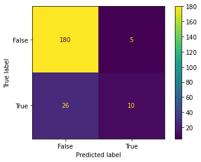

```python
conf_matrix("Logistic Regression", gs.best_estimator_)
```

## Model Training (SVM)

```python
from sklearn.svm import SVC

clf = SVC()

grid = [
  {
      'C': [0.001, 0.01, 0.1, 1, 10, 100, 1000],
      'gamma': ['scale', 'auto'],
      'kernel': ['linear','rbf'],
      'decision_function_shape': ['ovo', 'ovr']
  }
]

gs = GridSearchCV(
    estimator=clf,
    param_grid=grid,
    cv=skfold
)

start_time = time.time()
gs.fit(X_train, y_train)
end_time = time.time()
```

```python
start_time = time.time()
gs.best_estimator_.fit(X_train, y_train)
end_time = time.time()
print(f"It took {end_time - start_time} seconds to fit the train data")
```

```
It took 46.320271253585815 seconds to fit the train data
```

```python
gs.best_estimator_.get_params()
```

```
{'C': 1000,
 'break_ties': False,
 'cache_size': 200,
 'class_weight': None,
 'coef0': 0.0,
 'decision_function_shape': 'ovo',
 'degree': 3,
 'gamma': 'scale',
 'kernel': 'linear',
 'max_iter': -1,
 'probability': False,
 'random_state': None,
 'shrinking': True,
 'tol': 0.001,
 'verbose': False}
```

```python
gs.best_score_
```

```
0.8606843373493976
```

Store our best estimator

```python
svm_optimized = gs.best_estimator_
```

```python
print(evaluate_preds("SVM (Test)", gs.best_estimator_, 1))
```

```
The Training Duration for SVM (Test) Model is 0.003988742828369141 seconds.

Model Name: SVM (Test)
Accuracy: 0.8597285067873304
Precision: 0.8571428571428571
Recall: 0.16666666666666666
F1: 0.27906976744186046
ROC AUC: 0.5806306306306307
```

```
SVM Confusion Matrix
```

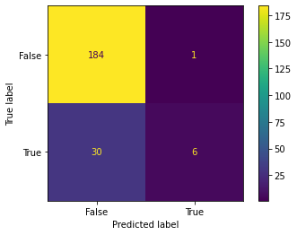

```python
conf_matrix("SVM", gs.best_estimator_)
```

## Model Training (Random Forest)

```python
from sklearn.ensemble import RandomForestClassifier

clf = RandomForestClassifier()

grid = [
    {
        'n_estimators': [50,100, 500],
        'max_features': ['log2', 'sqrt','auto'],
        'criterion': ['entropy', 'gini'],
        'max_depth': [5, 10, None],
        'min_samples_split': [2, 3, 5, 10],
        'min_samples_leaf': [1,3,5],
        'n_jobs': [-1]
    }
]

gs = GridSearchCV(
    estimator=clf,
    param_grid=grid,
    cv=skfold
)

start_time = time.time()
gs.fit(X_train, y_train)
end_time = time.time()
```

```python
start_time = time.time()
gs.best_estimator_.fit(X_train, y_train)
end_time = time.time()
print(f"It took {end_time - start_time} seconds to fit the train data")
```

```
It took 0.13932156562805176 seconds to fit the train data
```

```python
gs.best_estimator_.get_params()
```

```
{'bootstrap': True,
 'ccp_alpha': 0.0,
 'class_weight': None,
 'criterion': 'gini',
 'max_depth': 10,
 'max_features': 'sqrt',
 'max_leaf_nodes': None,
 'max_samples': None,
 'min_impurity_decrease': 0.0,
 'min_samples_leaf': 1,
 'min_samples_split': 2,
 'min_weight_fraction_leaf': 0.0,
 'n_estimators': 100,
 'n_jobs': -1,
 'oob_score': False,
 'random_state': None,
 'verbose': 0,
 'warm_start': False}
```

```python
gs.best_score_
```

```
0.8646971887550201
```

Store our best estimator

```python
rf_optimized = gs.best_estimator_
```

```python
print(evaluate_preds("Random Forest (Test)", gs.best_estimator_, 1))
```

```
The Training Duration for Random Forest (Test) Model is 0.020844221115112305 seconds.

Model Name: Random Forest (Test)
Accuracy: 0.8506787330316742
Precision: 0.6666666666666666
Recall: 0.16666666666666666
F1: 0.26666666666666666
ROC AUC: 0.5752252252252252
```

```
Random Forest Confusion Matrix
```

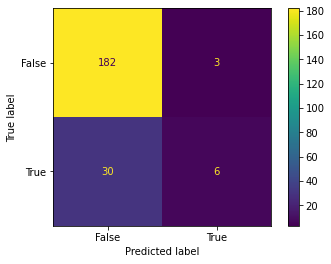

```python
conf_matrix("Random Forest", gs.best_estimator_)
```

## Model Comparisons (Evaluation Metrics and Train/Test Durations)

```python
print(evaluate_preds("Logistic Regression (Train)", gs.best_estimator_, 0))
```

```
The Training Duration for Logistic Regression (Train) Model is 0.029137372970581055 seconds.

Model Name: Logistic Regression (Train)
Accuracy: 0.9799839871897518
Precision: 1.0
Recall: 0.8756218905472637
F1: 0.9336870026525199
ROC AUC: 0.9378109452736318
```

```python
print(evaluate_preds("SVM (Train)", gs.best_estimator_, 0))
```

```
The Training Duration for SVM (Train) Model is 0.025115489959716797 seconds.

Model Name: SVM (Train)
Accuracy: 0.9799839871897518
Precision: 1.0
Recall: 0.8756218905472637
F1: 0.9336870026525199
ROC AUC: 0.9378109452736318
```

```python
print(evaluate_preds("Random Forest (Train)", gs.best_estimator_, 0))
```

```
The Training Duration for Random Forest (Train) Model is 0.02824258804321289 seconds.

Model Name: Random Forest (Train)
Accuracy: 0.9799839871897518
Precision: 1.0
Recall: 0.8756218905472637
F1: 0.9336870026525199
ROC AUC: 0.9378109452736318
```

```python
model_dict = {
    "Model": model_names,
    "Accuracy": accuracy_values,
    "Precision": precision_values,
    "Recall": recall_values,
    "F1 Score": f1_values,
    "ROC AUC": roc_auc_values
}
df = pd.DataFrame(model_dict)
df
```

|  | Model | Accuracy | Precision | Recall | F1 Score | ROC AUC |
| --- | --- | --- | --- | --- | --- | --- |
| 0 | Logistic Regression (Test) | 0.859729 | 0.666667 | 0.277778 | 0.392157 | 0.625375 |
| 1 | SVM (Test) | 0.859729 | 0.857143 | 0.166667 | 0.279070 | 0.580631 |
| 2 | Random Forest (Test) | 0.850679 | 0.666667 | 0.166667 | 0.266667 | 0.575225 |
| 3 | Logistic Regression (Train) | 0.979984 | 1.000000 | 0.875622 | 0.933687 | 0.937811 |
| 4 | SVM (Train) | 0.979984 | 1.000000 | 0.875622 | 0.933687 | 0.937811 |
| 5 | Random Forest (Train) | 0.979984 | 1.000000 | 0.875622 | 0.933687 | 0.937811 |

```python
train_durations
```

```
[0.029137372970581055, 0.025115489959716797, 0.02824258804321289]
```

```python
test_durations
```

```
[0.0, 0.003988742828369141, 0.020844221115112305]
```

```python
model_names
```

```
['Logistic Regression (Test)',
 'SVM (Test)',
 'Random Forest (Test)',
 'Logistic Regression (Train)',
 'SVM (Train)',
 'Random Forest (Train)']
```

```python
durations = test_durations
for dur in train_durations:
    test_durations.append(dur)
duration_dict = {
    "Model": model_names,
    "Durations (seconds)": durations
}
print(durations)
df = pd.DataFrame(duration_dict)
df
```

```
[0.0, 0.003988742828369141, 0.020844221115112305, 0.029137372970581055, 0.025115489959716797, 0.02824258804321289]
```

|  | Model | Durations (seconds) |
| --- | --- | --- |
| 0 | Logistic Regression (Test) | 0.000000 |
| 1 | SVM (Test) | 0.003989 |
| 2 | Random Forest (Test) | 0.020844 |
| 3 | Logistic Regression (Train) | 0.029137 |
| 4 | SVM (Train) | 0.025115 |
| 5 | Random Forest (Train) | 0.028243 |

## Picking the Best Model and 5 Most Important Features

It is clear that the best Model for this Binary Classification problem is Logistic Regression

Now Let's use the best estimator with the 5 most important features and test it once again.

```python
def get_feature_importance(clf, feature_names):

    print(len(clf.coef_[0]))
    print(len(feature_names))

    feature_importance = (
        pd.DataFrame(
            {
                'variable': feature_names,
                'coefficient': clf.coef_[0]
            }
        )
        .round(decimals=2) \
        .sort_values('coefficient', ascending=False) \
        .style.bar(color=['red', 'green'], align='zero')
    )
    return feature_importance
```

```python
df_columns = df_columns.drop("Attrition")
get_feature_importance(lg_optimized, df_columns)
```

```
21
21
```

|  | variable | coefficient |
| --- | --- | --- |
| 14 | OverTime | 0.890000 |
| 2 | Department | 0.300000 |
| 11 | MaritalStatus | 0.220000 |
| 7 | Gender | 0.170000 |
| 1 | BusinessTravel | 0.160000 |
| 13 | NumCompaniesWorked | 0.070000 |
| 20 | YearsSinceLastPromotion | 0.030000 |
| 3 | DistanceFromHome | 0.020000 |
| 4 | Education | 0.000000 |
| 5 | EducationField | 0.000000 |
| 9 | JobRole | -0.020000 |
| 15 | PerformanceRating | -0.050000 |
| 18 | TrainingTimesLastYear | -0.050000 |
| 16 | RelationshipSatisfaction | -0.110000 |
| 19 | WorkLifeBalance | -0.130000 |
| 17 | StockOptionLevel | -0.140000 |
| 6 | EnvironmentSatisfaction | -0.150000 |
| 10 | JobSatisfaction | -0.170000 |
| 8 | JobInvolvement | -0.290000 |
| 0 | Age | -0.670000 |
| 12 | MonthlyIncome | -1.490000 |

```python
employee_data
```

|  | Age | Attrition | BusinessTravel | Department | DistanceFromHome | Education | EducationField | EnvironmentSatisfaction | Gender | JobInvolvement | ... | MaritalStatus | MonthlyIncome | NumCompaniesWorked | OverTime | PerformanceRating | RelationshipSatisfaction | StockOptionLevel | TrainingTimesLastYear | WorkLifeBalance | YearsSinceLastPromotion |
| --- | --- | --- | --- | --- | --- | --- | --- | --- | --- | --- | --- | --- | --- | --- | --- | --- | --- | --- | --- | --- | --- |
| 0 | 0.547619 | 1 | 1 | 2 | 1 | 2 | 1 | 2 | 0 | 3 | ... | 2 | 0.262454 | 8 | 1 | 3 | 1 | 0 | 0 | 1 | 0 |
| 1 | 0.738095 | 0 | 3 | 1 | 8 | 1 | 1 | 3 | 1 | 2 | ... | 1 | 0.217009 | 1 | 0 | 4 | 4 | 1 | 3 | 3 | 1 |
| 2 | 0.452381 | 1 | 1 | 1 | 2 | 2 | 4 | 4 | 1 | 2 | ... | 2 | 0.056925 | 6 | 1 | 3 | 2 | 0 | 3 | 3 | 0 |
| 3 | 0.357143 | 0 | 3 | 1 | 3 | 4 | 1 | 4 | 0 | 3 | ... | 1 | 0.100053 | 1 | 1 | 3 | 3 | 0 | 3 | 3 | 3 |
| 4 | 0.214286 | 0 | 1 | 1 | 2 | 1 | 3 | 1 | 1 | 3 | ... | 1 | 0.129489 | 9 | 0 | 3 | 4 | 1 | 3 | 3 | 2 |
| ... | ... | ... | ... | ... | ... | ... | ... | ... | ... | ... | ... | ... | ... | ... | ... | ... | ... | ... | ... | ... | ... |
| 1465 | 0.428571 | 0 | 3 | 1 | 23 | 2 | 3 | 3 | 1 | 4 | ... | 1 | 0.082254 | 4 | 0 | 3 | 3 | 1 | 3 | 3 | 0 |
| 1466 | 0.500000 | 0 | 1 | 1 | 6 | 1 | 3 | 4 | 1 | 2 | ... | 1 | 0.472986 | 4 | 0 | 3 | 1 | 1 | 5 | 3 | 1 |
| 1467 | 0.214286 | 0 | 1 | 1 | 4 | 3 | 1 | 2 | 1 | 4 | ... | 1 | 0.270300 | 1 | 1 | 4 | 2 | 1 | 0 | 3 | 0 |
| 1468 | 0.738095 | 0 | 3 | 2 | 2 | 3 | 3 | 4 | 1 | 2 | ... | 1 | 0.230700 | 2 | 0 | 3 | 4 | 0 | 3 | 2 | 0 |
| 1469 | 0.380952 | 0 | 1 | 1 | 8 | 3 | 3 | 2 | 1 | 4 | ... | 1 | 0.178778 | 2 | 0 | 3 | 1 | 0 | 3 | 4 | 1 |

1470 rows × 22 columns

```python
employee_data_with_five_features = pd.DataFrame({
    "OverTime": employee_data["OverTime"],
    "MonthlyIncome": employee_data['MonthlyIncome'],
    "Age": employee_data["Age"],
    "Department": employee_data['Department'],
    "JobInvolvement": employee_data['JobInvolvement'],
    "Attrition": employee_data['Attrition']
})
employee_data_with_five_features
```

|  | OverTime | MonthlyIncome | Age | Department | JobInvolvement | Attrition |
| --- | --- | --- | --- | --- | --- | --- |
| 0 | 1 | 0.262454 | 0.547619 | 2 | 3 | 1 |
| 1 | 0 | 0.217009 | 0.738095 | 1 | 2 | 0 |
| 2 | 1 | 0.056925 | 0.452381 | 1 | 2 | 1 |
| 3 | 1 | 0.100053 | 0.357143 | 1 | 3 | 0 |
| 4 | 0 | 0.129489 | 0.214286 | 1 | 3 | 0 |
| ... | ... | ... | ... | ... | ... | ... |
| 1465 | 0 | 0.082254 | 0.428571 | 1 | 4 | 0 |
| 1466 | 0 | 0.472986 | 0.500000 | 1 | 2 | 0 |
| 1467 | 1 | 0.270300 | 0.214286 | 1 | 4 | 0 |
| 1468 | 0 | 0.230700 | 0.738095 | 2 | 2 | 0 |
| 1469 | 0 | 0.178778 | 0.380952 | 1 | 4 | 0 |

1470 rows × 6 columns

```python
X_five = employee_data_with_five_features.drop("Attrition", axis=1)
y_five = employee_data_with_five_features["Attrition"]

np.random.seed(12345)

X_train_five, X_test_five, y_train_five, y_test_five = train_test_split(X_five,y_five,test_size=0.15,stratify=y)
```

```python
lg_optimized_five_features = LogisticRegression(C=1.0,max_iter=100,multi_class="multinomial",penalty="l2",solver="lbfgs")
lg_optimized_five_features.fit(X_train_five, y_train_five)
```

```
LogisticRegression(multi_class='multinomial')
```

```python
y_preds_five = lg_optimized_five_features.predict(X_test_five)
```

```python
print("Optimized Logistic Regression with 5 features Evaluation Metrics")
res = f'''
Accuracy : {accuracy_score(y_test_five,y_preds_five)}
Precision: {precision_score(y_test_five,y_preds_five)}
Recall: {recall_score(y_test_five, y_preds_five)}
F1: {f1_score(y_test_five, y_preds_five)}
ROC AUC: {roc_auc_score(y_test_five, y_preds_five)}
'''
print(res)
```

```
Optimized Logistic Regression with 5 features Evaluation Metrics

Accuracy : 0.832579185520362
Precision: 0.4444444444444444
Recall: 0.1111111111111111
F1: 0.17777777777777776
ROC AUC: 0.5420420420420421
```

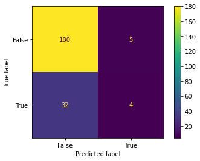

```python
cm_display = metrics.ConfusionMatrixDisplay(confusion_matrix = confusion_matrix(y_test_five, y_preds_five), display_labels = [False, True])
cm_display.plot()
plt.show()
```

## Model and DataFrame Storing (Pickle)

In here I created two pickle files

- One of them is containing the best model.
- The other is containing the preprocessed data.

```python
import pickle

best_model = lg_optimized

pickle.dump(best_model, open('model.pickle', 'wb'))

preprocessed_data = pickle.dump(employee_data, open('preprocessing.pickle', 'wb'))
```